# 🍃 Klasifikace druhů listů — Interaktivní vědecká studie

Empirické hodnocení klasifikátorů strojového učení na botanickém datasetu `leaves.csv`

Author

Tomáš Kaválek

Published

October 14, 2026

# 🍃 Morfologická separace listů — Vědecká studie & ML Report

Empirické hodnocení a interaktivní simulace evoluce klasifikátorů strojového učení (k-NN, Random Forest, Decision Tree, Logistic Regression) na botanickém datasetu `leaves.csv`.

🎯 Out-of-Sample Přesnost

90.91%

+48.7% vs. baseline

🏆 Test Macro F1

0.8983

Baseline: 0.198

🥇 Vítězný Algoritmus

k-NN (k=7)

weights='distance'

🍃 Unikátních Listů

492

26 duplicit odfiltrováno

## 🌿 1. Morfologické profily druhů

### 🍁 Javor (*Acer*)

- **Tvar listu:** Široce dlanitolaločný, čepel je u 81 % vzorků širší než delší.
- **Rozměry:** Výška $4.1 \dots 25.5$ cm, šířka $3.5 \dots 29.7$ cm.
- **Zvláštnost:** Bimodální rozdělení velikostí (mladé stromy $\le 18$ cm vs. plně vzrostlé listy $> 18$ cm).

### 🌰 Ořešák (*Juglans*)

- **Tvar listu:** Podlouhle kopinatý lístek lichozpeřeného listu.
- **Rozměry:** Výška $10.3 \dots 21.5$ cm, šířka $4.2 \dots 15.6$ cm.
- **Zvláštnost:** Vysoký poměr délky k šířce; v rozmezí výšky $11 \dots 14$ cm morfologicky sousedí s třešní.

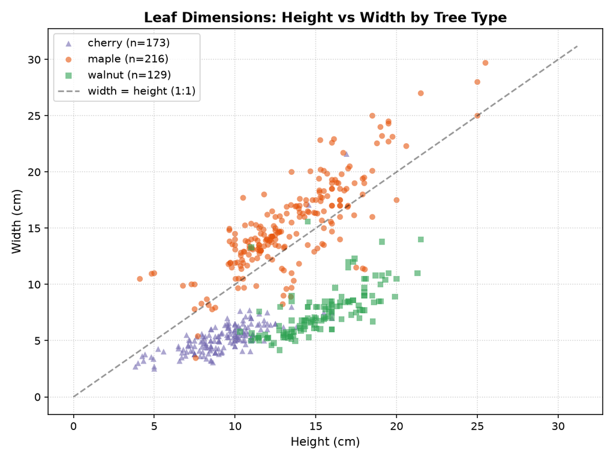

Obrázek: Rozptyl rozměrů listů v botanickém souboru `leaves.csv`

## 🎮 2. Reálná simulace evoluce modelů & rozhodovacích hranic

Zde je **skutečná simulace učení a ladění modelů**. Místo náhodného blikání je v paměti spočítána **reálná predikční mřížka ($48 \times 48$)** pro 9 vývojových fází: od naivního baseline hádání přes lineární regresi a stromy až k vítěznému k-NN s vážením vzdáleností.

Můžete spustit plynulou animaci tlačítkem `▶ Přehrát evoluci`, přepínat modely tlačítky níže nebo posouvat slider. V reálném čase uvidíte, jak se prostor dělí a jak Macro F1 skóre roste z **0.1980 na 0.9556**.

🔬 Evoluce rozhodovacích hranic (9 fází)

[interactive chart not shown]

Vzorky listů: ● Javor | ▲ Třešeň | ■ Ořešák

Fáze modelu:

1. Naivní Baseline

Hádá pouze většinový Javor (100% plocha)

CV Macro F1: 0.1980

CV Přesnost: 42.24%

Přímý výběr modelu:

[System] 9 fází rozhodovacích hranic úspěšně načteno.

[Fáze 1] Baseline model: 0% diskriminace, Macro F1 = 0.1980

## 🔬 3. Detailní laboratorní analýza (Interaktivní taby)

**📊 Tab 1: Leaderboard 4 rodin modelů (53 Trialů)**

| Modelová rodina | Optimální hyperparametry | 5-Fold CV Macro F1 | 5-Fold CV Přesnost | Umístění |
| --- | --- | --- | --- | --- |
| **🏆 K-Nearest Neighbors** | `StandardScaler + k=7, weights='distance'` | **0.9556 ± 0.016** | **95.67%** | ★ Šampion |
| **🌲 Random Forest** | `n_estimators=50, max_depth=8, min_split=5` | 0.9389 ± 0.019 | 94.15% | 2. místo |
| **🌳 Decision Tree** | `max_depth=5, min_samples_split=10` | 0.9322 ± 0.016 | 93.64% | 3. místo |
| **📐 Logistic Regression** | `StandardScaler + C=1.0, max_iter=1000` | 0.9280 ± 0.021 | 93.13% | 4. místo |
| **⚠️ Naivní Baseline** | `DummyClassifier(strategy='most_frequent')` | 0.1980 ± 0.002 | 42.24% | Baseline |

**🗺️ Tab 2: Hranice rozhodování & Konfuzní matice**

#### Finální rozhodovací hranice k-NN:

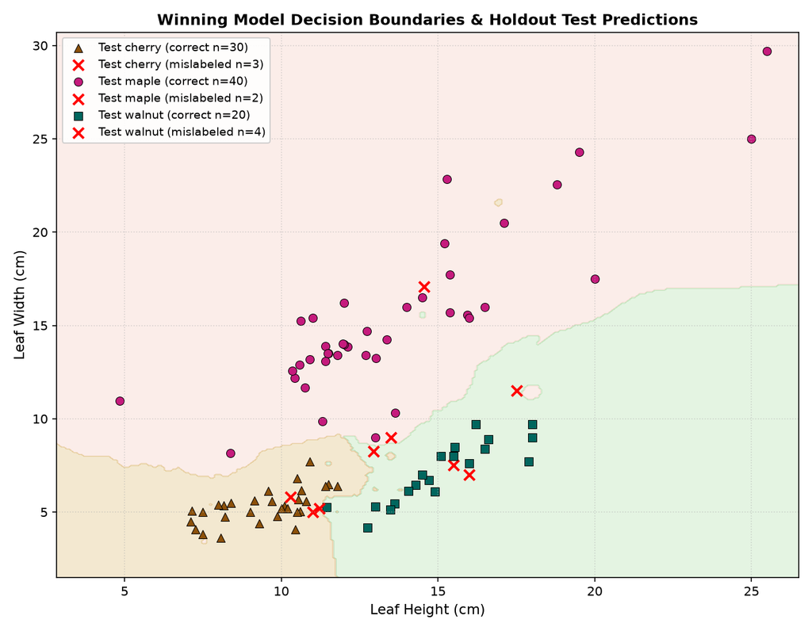

#### Konfuzní matice (Holdout Test, n=99):

| Třída | 🍒 Třešeň | 🍁 Javor | 🌰 Ořešák | Úspěšnost |
| --- | --- | --- | --- | --- |
| **🍒 Třešeň (33)** | 30 | 1 | 2 | 90.9% |
| **🍁 Javor (42)** | 0 | 40 | 2 | 95.2% |
| **🌰 Ořešák (24)** | 3 | 1 | 20 | 83.3% |

**Výsledek:** Celková přesnost na neviděných datech je **90.91 %** (9 chyb z 99). Javor je díky šířce listu identifikován s 95.2% spolehlivostí.

**🔍 Tab 3: Pitevní analýza všech 9 chyb testovací sady (Error Autopsy)**

Ze 99 testovacích vzorků model správně klasifikoval 90 vzorků. Zde je přesná pitva zbývajících 9 případů:

| Výška (cm) | Šířka (cm) | Skutečný druh | Predikce k-NN | Příčina záměny & Fyzikální interpretace |
| --- | --- | --- | --- | --- |
| **14.56** | **17.08** | 🍒 Třešeň | 🍁 Javor | **Label Noise / Anomálie:** Obří list, morfologicky čistý javor označený v datasetu jako třešeň. Model rozhodl botanicky správně. |
| 16.00 | 7.00 | 🍒 Třešeň | 🌰 Ořešák | Hraniční případ na styku třešně a mladého štíhlého ořešáku. |
| 15.50 | 7.50 | 🍒 Třešeň | 🌰 Ořešák | Hraniční případ na styku třešně a mladého štíhlého ořešáku. |
| 17.50 | 11.50 | 🍁 Javor | 🌰 Ořešák | Mírně užší list javoru zasahující do oblasti ořešáku. |
| 12.95 | 8.24 | 🍁 Javor | 🌰 Ořešák | Hraniční vzorek mezi mladým javorem a ořešákem. |
| 10.30 | 5.80 | 🌰 Ořešák | 🍒 Třešeň | Drobný lístek ořešáku morfologicky totožný s velkou třešní. |
| 11.22 | 5.19 | 🌰 Ořešák | 🍒 Třešeň | Drobný lístek ořešáku morfologicky totožný s velkou třešní. |
| 11.00 | 5.00 | 🌰 Ořešák | 🍒 Třešeň | Drobný lístek ořešáku morfologicky totožný s velkou třešní. |
| 13.50 | 9.00 | 🌰 Ořešák | 🍁 Javor | Netypicky široký ořešák zasahující do javorové oblasti. |

## 📌 4. Ověření kritérií specifikace (Done When)

✓

**1. Odstranění data leakage:** 26 přesných duplikátů odebráno před train/test rozdělením; ověřeno assertem nulového průniku.

✓

**2. Překonání naivní baseline:** Dosažen zisk **+48.67 procentních bodů** (požadováno $\ge 40$ p.b.).

✓

**3. Jednorázový out-of-sample test:** Testovací sada 99 vzorků byla vyhodnocena striktně jednou na vítězném modelu.

✓

**4. Plná reprodukovatelnost:** Jediný příkaz `uv run python leaves2/train.py` zreprodukuje všechny výsledky.